# Phase 1B EFA - STARS, RMARS, STARS_M, & RMARS_S

Jenny Terry

10/06/2020

First, read in the cleaned, anonymised data.

```r
# read in anonymised data file
statanx_data <- readr::read_csv(here::here("data", "anon_data.csv"))
# check first few rows
head(statanx_data)
```

```
## # A tibble: 6 x 157
##   id    q4.1_1 q4.1_2 q4.1_3 q4.1_4 q4.1_5 q4.1_6 q4.1_7 q4.1_8 q4.1_9 q4.1_10
##   <chr>  <dbl>  <dbl>  <dbl>  <dbl>  <dbl>  <dbl>  <dbl>  <dbl>  <dbl>   <dbl>
## 1 jroWw      5      3      2      3      3      3      3      5      1       4
## 2 DMP8X      2      1      1      1      1      1      2      1      1       1
## 3 Jebht      3      3      2      3      4      3      5      5      1       5
## 4 1W4o3      4      2      4      5      4      3      5      5      3       5
## 5 fdzgn      4      3      3      2      3      2      4      4      1       3
## 6 Trng5      5      5      5      5      4      5      5      5      2       5
## # ... with 146 more variables: q4.1_11 <dbl>, q4.1_12 <dbl>, q4.1_13 <dbl>,
## #   q4.1_14 <dbl>, q4.1_15 <dbl>, q4.1_16 <dbl>, q4.1_17 <dbl>, q4.1_18 <dbl>,
## #   q4.1_19 <dbl>, q4.1_20 <dbl>, q4.1_21 <dbl>, q4.1_22 <dbl>, q4.1_23 <dbl>,
## #   q4.2_1 <dbl>, q4.2_2 <dbl>, q4.2_3 <dbl>, q4.2_4 <dbl>, q4.2_5 <dbl>,
## #   q4.2_6 <dbl>, q4.2_7 <dbl>, q4.2_8 <dbl>, q4.2_9 <dbl>, q4.2_10 <dbl>,
## #   q4.2_11 <dbl>, q4.2_12 <dbl>, q4.2_13 <dbl>, q4.2_14 <dbl>, q4.2_15 <dbl>,
## #   q4.2_16 <dbl>, q4.2_17 <dbl>, q4.2_18 <dbl>, q4.2_19 <dbl>, q4.2_20 <dbl>,
## #   q4.3_1 <dbl>, q4.3_2 <dbl>, q4.3_3 <dbl>, q4.3_4 <dbl>, q4.3_5 <dbl>,
## #   q4.3_6 <dbl>, q4.3_7 <dbl>, q4.3_8 <dbl>, q4.3_9 <dbl>, q4.3_10 <dbl>,
## #   q4.3_11 <dbl>, q4.3_12 <dbl>, q4.3_13 <dbl>, q4.3_14 <dbl>, q4.3_15 <dbl>,
## #   q4.3_16 <dbl>, q4.3_17 <dbl>, q4.3_18 <dbl>, q4.3_19 <dbl>, q4.3_20 <dbl>,
## #   q4.4_1 <dbl>, q4.4_2 <dbl>, q4.4_3 <dbl>, q4.4_4 <dbl>, q4.4_5 <dbl>,
## #   q4.4_6 <dbl>, q4.4_7 <dbl>, q4.4_8 <dbl>, q4.4_9 <dbl>, q4.4_10 <dbl>,
## #   q4.4_11 <dbl>, q4.4_12 <dbl>, q4.4_13 <dbl>, q4.4_14 <dbl>, q4.4_15 <dbl>,
## #   q4.4_16 <dbl>, q4.4_17 <dbl>, q4.4_18 <dbl>, q4.4_19 <dbl>, q5.1_1 <dbl>,
## #   q5.1_2 <dbl>, q5.1_3 <dbl>, q5.1_4 <dbl>, q5.1_5 <dbl>, q5.1_6 <dbl>,
## #   q5.1_7 <dbl>, q5.1_8 <dbl>, q5.1_9 <dbl>, q5.1_10 <dbl>, q5.1_11 <dbl>,
## #   q5.1_12 <dbl>, q5.1_13 <dbl>, q5.1_14 <dbl>, q5.1_15 <dbl>, q5.1_16 <dbl>,
## #   q5.1_17 <dbl>, q5.1_18 <dbl>, q5.1_19 <dbl>, q5.1_20 <dbl>, q5.1_21 <dbl>,
## #   q5.2_1 <dbl>, q5.2_2 <dbl>, q5.2_3 <dbl>, q5.2_4 <dbl>, q5.2_5 <dbl>,
## #   q5.2_6 <dbl>, q5.2_7 <dbl>, ...
```

```r
# prepare dataset for factor analysis
ph1b_fa_data <- dplyr::select(statanx_data, q4.1_1:q4.4_19)

# check dataset
head(ph1b_fa_data)
```

```
## # A tibble: 6 x 82
##   q4.1_1 q4.1_2 q4.1_3 q4.1_4 q4.1_5 q4.1_6 q4.1_7 q4.1_8 q4.1_9 q4.1_10 q4.1_11
##    <dbl>  <dbl>  <dbl>  <dbl>  <dbl>  <dbl>  <dbl>  <dbl>  <dbl>   <dbl>   <dbl>
## 1      5      3      2      3      3      3      3      5      1       4       3
## 2      2      1      1      1      1      1      2      1      1       1       1
## 3      3      3      2      3      4      3      5      5      1       5       4
## 4      4      2      4      5      4      3      5      5      3       5       3
## 5      4      3      3      2      3      2      4      4      1       3       2
## 6      5      5      5      5      4      5      5      5      2       5       5
## # ... with 71 more variables: q4.1_12 <dbl>, q4.1_13 <dbl>, q4.1_14 <dbl>,
## #   q4.1_15 <dbl>, q4.1_16 <dbl>, q4.1_17 <dbl>, q4.1_18 <dbl>, q4.1_19 <dbl>,
## #   q4.1_20 <dbl>, q4.1_21 <dbl>, q4.1_22 <dbl>, q4.1_23 <dbl>, q4.2_1 <dbl>,
## #   q4.2_2 <dbl>, q4.2_3 <dbl>, q4.2_4 <dbl>, q4.2_5 <dbl>, q4.2_6 <dbl>,
## #   q4.2_7 <dbl>, q4.2_8 <dbl>, q4.2_9 <dbl>, q4.2_10 <dbl>, q4.2_11 <dbl>,
## #   q4.2_12 <dbl>, q4.2_13 <dbl>, q4.2_14 <dbl>, q4.2_15 <dbl>, q4.2_16 <dbl>,
## #   q4.2_17 <dbl>, q4.2_18 <dbl>, q4.2_19 <dbl>, q4.2_20 <dbl>, q4.3_1 <dbl>,
## #   q4.3_2 <dbl>, q4.3_3 <dbl>, q4.3_4 <dbl>, q4.3_5 <dbl>, q4.3_6 <dbl>,
## #   q4.3_7 <dbl>, q4.3_8 <dbl>, q4.3_9 <dbl>, q4.3_10 <dbl>, q4.3_11 <dbl>,
## #   q4.3_12 <dbl>, q4.3_13 <dbl>, q4.3_14 <dbl>, q4.3_15 <dbl>, q4.3_16 <dbl>,
## #   q4.3_17 <dbl>, q4.3_18 <dbl>, q4.3_19 <dbl>, q4.3_20 <dbl>, q4.4_1 <dbl>,
## #   q4.4_2 <dbl>, q4.4_3 <dbl>, q4.4_4 <dbl>, q4.4_5 <dbl>, q4.4_6 <dbl>,
## #   q4.4_7 <dbl>, q4.4_8 <dbl>, q4.4_9 <dbl>, q4.4_10 <dbl>, q4.4_11 <dbl>,
## #   q4.4_12 <dbl>, q4.4_13 <dbl>, q4.4_14 <dbl>, q4.4_15 <dbl>, q4.4_16 <dbl>,
## #   q4.4_17 <dbl>, q4.4_18 <dbl>, q4.4_19 <dbl>
```

The question/item numbers need to be converted to meaningful names for easier interpretation.

(I know this code is awful but I’ve already wasted too many hours trying to improve it so this will have to do for now!)

```r
ph1b_fa_data %<>%
  dplyr::rename(
    stars_test1 = q4.1_1,
    stars_int1 = q4.1_2,
    stars_help1 = q4.1_3,
    stars_test2 = q4.1_4,
    stars_int2 = q4.1_5,
    stars_int3 = q4.1_6,
    stars_int4 = q4.1_7,
    stars_test3 = q4.1_8,
    stars_int5 = q4.1_9,
    stars_test4 = q4.1_10,
    stars_int6 = q4.1_11,
    stars_int7 = q4.1_12,
    stars_test5 = q4.1_13,
    stars_int8 = q4.1_14,
    stars_test6 = q4.1_15,
    stars_help2 = q4.1_16,
    stars_int9 = q4.1_17,
    stars_int10 = q4.1_18,
    stars_help3 = q4.1_19,
    stars_int11 = q4.1_20,
    stars_test7 = q4.1_21,
    stars_test8 = q4.1_22,
    stars_help4 = q4.1_23,
    stars_m_test1 = q4.2_1,
    stars_m_int1 = q4.2_2,
    stars_m_help1 = q4.2_3,
    stars_m_test2 = q4.2_4,
    stars_m_int2 = q4.2_5,
    stars_m_int3 = q4.2_6,
    stars_m_int4 = q4.2_7,
    stars_m_test3 = q4.2_8,
    stars_m_test4 = q4.2_9,
    stars_m_int6 = q4.2_10,
    stars_m_test5 = q4.2_11,
    stars_m_int8 = q4.2_12,
    stars_m_test6 = q4.2_13,
    stars_m_help2 = q4.2_14,
    stars_m_int10 = q4.2_15,
    stars_m_help3 = q4.2_16,
    stars_m_int11 = q4.2_17,
    stars_m_test7 = q4.2_18,
    stars_m_test8 = q4.2_19,
    stars_m_help4 = q4.2_20,
    rmars_test1 = q4.3_1,
    rmars_test2 = q4.3_2,
    rmars_test3 = q4.3_3,
    rmars_test4 = q4.3_4,
    rmars_test5 = q4.3_5,
    rmars_test6 = q4.3_6,
    rmars_test7 = q4.3_7,
    rmars_test8 = q4.3_8,
    rmars_test9 = q4.3_9,
    rmars_test10 = q4.3_10,
    rmars_num1 = q4.3_11,
    rmars_num2 = q4.3_12,
    rmars_num3 = q4.3_13,
    rmars_num4 = q4.3_14,
    rmars_num5 = q4.3_15,
    rmars_course1 = q4.3_16,
    rmars_course2 = q4.3_17,
    rmars_course3 = q4.3_18,
    rmars_course4 = q4.3_19,
    rmars_course5 = q4.3_20,
    rmars_s_test1 = q4.4_1,
    rmars_s_test2 = q4.4_2,
    rmars_s_test3 = q4.4_3,
    rmars_s_test4 = q4.4_4,
    rmars_s_test5 = q4.4_5,
    rmars_s_test6 = q4.4_6,
    rmars_s_test7 = q4.4_7,
    rmars_s_test8 = q4.4_8,
    rmars_s_test9 = q4.4_9,
    rmars_s_test10 = q4.4_10,
    rmars_s_num2 = q4.4_11,
    rmars_s_num3 = q4.4_12,
    rmars_s_num4 = q4.4_13,
    rmars_s_num5 = q4.4_14,
    rmars_s_course1 = q4.4_15,
    rmars_s_course2 = q4.4_16,
    rmars_s_course3 = q4.4_17,
    rmars_s_course4 = q4.4_18,
    rmars_s_course5 = q4.4_19)
```

```r
# descriptive statistics
psych::describe(ph1b_fa_data)
```

```
##                 vars   n mean   sd median trimmed  mad min max range  skew
## stars_test1        1 465 3.37 1.14      3    3.41 1.48   1   5     4 -0.25
## stars_int1         2 465 2.68 1.15      3    2.64 1.48   1   5     4  0.27
## stars_help1        3 465 3.04 1.32      3    3.05 1.48   1   5     4  0.03
## stars_test2        4 465 3.40 1.13      3    3.42 1.48   1   5     4 -0.15
## stars_int2         5 465 2.72 1.18      3    2.69 1.48   1   5     4  0.15
## stars_int3         6 465 2.36 1.08      2    2.29 1.48   1   5     4  0.47
## stars_int4         7 465 3.52 1.06      4    3.57 1.48   1   5     4 -0.31
## stars_test3        8 465 3.95 1.05      4    4.08 1.48   1   5     4 -0.75
## stars_int5         9 465 1.97 1.11      2    1.80 1.48   1   5     4  0.95
## stars_test4       10 465 3.70 1.15      4    3.80 1.48   1   5     4 -0.59
## stars_int6        11 465 2.60 1.20      2    2.54 1.48   1   5     4  0.29
## stars_int7        12 465 2.81 1.23      3    2.76 1.48   1   5     4  0.20
## stars_test5       13 465 3.38 1.08      3    3.40 1.48   1   5     4 -0.20
## stars_int8        14 465 2.57 1.18      2    2.51 1.48   1   5     4  0.34
## stars_test6       15 465 3.77 1.13      4    3.87 1.48   1   5     4 -0.63
## stars_help2       16 465 2.83 1.24      3    2.79 1.48   1   5     4  0.15
## stars_int9        17 465 2.08 1.12      2    1.93 1.48   1   5     4  0.85
## stars_int10       18 465 2.52 1.27      2    2.43 1.48   1   5     4  0.39
## stars_help3       19 465 2.83 1.24      3    2.78 1.48   1   5     4  0.19
## stars_int11       20 465 2.78 1.19      3    2.75 1.48   1   5     4  0.18
## stars_test7       21 465 2.74 1.28      3    2.68 1.48   1   5     4  0.23
## stars_test8       22 465 3.05 1.25      3    3.06 1.48   1   5     4  0.03
## stars_help4       23 465 2.63 1.21      2    2.57 1.48   1   5     4  0.33
## stars_m_test1     24 465 3.21 1.17      3    3.23 1.48   1   5     4 -0.08
## stars_m_int1      25 465 2.54 1.13      2    2.50 1.48   1   5     4  0.31
## stars_m_help1     26 465 2.91 1.29      3    2.89 1.48   1   5     4  0.05
## stars_m_test2     27 465 3.13 1.17      3    3.13 1.48   1   5     4  0.00
## stars_m_int2      28 465 2.62 1.10      3    2.59 1.48   1   5     4  0.22
## stars_m_int3      29 465 2.43 1.10      2    2.37 1.48   1   5     4  0.44
## stars_m_int4      30 465 2.78 1.13      3    2.75 1.48   1   5     4  0.29
## stars_m_test3     31 465 3.74 1.16      4    3.84 1.48   1   5     4 -0.54
## stars_m_test4     32 465 3.61 1.18      4    3.70 1.48   1   5     4 -0.48
## stars_m_int6      33 465 1.86 1.08      1    1.67 0.00   1   5     4  1.16
## stars_m_test5     34 465 3.36 1.08      3    3.37 1.48   1   5     4 -0.15
## stars_m_int8      35 465 2.71 1.12      3    2.68 1.48   1   5     4  0.21
## stars_m_test6     36 465 3.67 1.10      4    3.75 1.48   1   5     4 -0.48
## stars_m_help2     37 465 2.76 1.22      3    2.70 1.48   1   5     4  0.26
## stars_m_int10     38 465 2.48 1.27      2    2.39 1.48   1   5     4  0.43
## stars_m_help3     39 465 2.83 1.21      3    2.80 1.48   1   5     4  0.08
```

[output cut: 111 more lines]

```
## rmars_s_test5      -0.81 0.05
## rmars_s_test6      -0.50 0.05
## rmars_s_test7       0.00 0.05
## rmars_s_test8      -1.12 0.06
## rmars_s_test9       0.11 0.05
## rmars_s_test10      0.14 0.05
## rmars_s_num2       -1.06 0.06
## rmars_s_num3       -1.08 0.06
## rmars_s_num4       -1.03 0.06
## rmars_s_num5       -1.03 0.06
## rmars_s_course1     1.27 0.05
## rmars_s_course2    -0.72 0.05
## rmars_s_course3    -0.91 0.06
## rmars_s_course4    -0.89 0.06
## rmars_s_course5    -0.42 0.05
```

We can obtain correlations using FIML (so that we don’t lose cases to pairwise deletion) by first calculating the covariance matrix (which will also be used for factor analysis) and then converting the covariances to correlations.

```r
# covariance matrix using fiml
ph1b_fa_cov <- psych::corFiml(ph1b_fa_data)
```

```r
# descriptive correlations
ph1b_fa_corr <- cov2cor(ph1b_fa_cov)
ph1b_fa_corr
```

```
##                 stars_test1 stars_int1 stars_help1 stars_test2 stars_int2
## stars_test1       1.0000000  0.4253733   0.3661977   0.6182067  0.4400480
## stars_int1        0.4253733  1.0000000   0.3048657   0.4628098  0.5985503
## stars_help1       0.3661977  0.3048657   1.0000000   0.3775558  0.2929680
## stars_test2       0.6182067  0.4628098   0.3775558   1.0000000  0.4467228
## stars_int2        0.4400480  0.5985503   0.2929680   0.4467228  1.0000000
## stars_int3        0.4449550  0.6434631   0.3152697   0.4813334  0.5724508
## stars_int4        0.4816340  0.5104502   0.3621459   0.4557057  0.5297927
## stars_test3       0.5733737  0.3915548   0.3618851   0.5817213  0.4546055
## stars_int5        0.2234860  0.3887840   0.2573132   0.2279259  0.4194409
## stars_test4       0.4879638  0.3093325   0.2833854   0.4740432  0.3643450
## stars_int6        0.4072546  0.5771863   0.2652609   0.4066458  0.6241044
## stars_int7        0.4600574  0.5773652   0.4430695   0.5037782  0.5253394
## stars_test5       0.4495064  0.3859730   0.4011377   0.4095719  0.3702146
## stars_int8        0.3544455  0.4497429   0.2990358   0.3505030  0.5557877
## stars_test6       0.5786448  0.3284584   0.3130532   0.4839048  0.3688454
## stars_help2       0.3250572  0.3160400   0.8320650   0.3824475  0.3177827
## stars_int9        0.2652870  0.4627640   0.2120171   0.2591899  0.4386553
## stars_int10       0.4309782  0.5116941   0.3403817   0.4427855  0.5129482
## stars_help3       0.3171774  0.3514376   0.7255805   0.3946834  0.3348457
## stars_int11       0.4437038  0.6583981   0.3120550   0.5005795  0.6179280
## stars_test7       0.5669998  0.4822205   0.3408054   0.5338740  0.5044611
## stars_test8       0.4452566  0.3638289   0.3424032   0.3931776  0.3690902
## stars_help4       0.3441422  0.3880010   0.6584917   0.3721670  0.3451684
## stars_m_test1     0.6235516  0.3289604   0.2973166   0.5433724  0.3990736
## stars_m_int1      0.3928073  0.6677927   0.2675332   0.4300514  0.5714517
## stars_m_help1     0.3295621  0.2454330   0.7858971   0.3714389  0.2613636
## stars_m_test2     0.5500216  0.3920241   0.3363775   0.6456161  0.4058269
## stars_m_int2      0.3717377  0.4805576   0.2727848   0.3977947  0.6274850
## stars_m_int3      0.4015612  0.5621945   0.2487956   0.3990416  0.5162226
## stars_m_int4      0.4311096  0.4682665   0.3532794   0.4569703  0.5230017
## stars_m_test3     0.4665288  0.2370717   0.2449604   0.4335944  0.2898032
## stars_m_test4     0.3772312  0.2666357   0.2589447   0.3856842  0.2912881
## stars_m_int6      0.2415495  0.3678653   0.1331052   0.1990985  0.3890297
## stars_m_test5     0.3970145  0.3372771   0.3280653   0.3676579  0.3439215
## stars_m_int8      0.3947646  0.4663515   0.3082480   0.3930075  0.5060140
## stars_m_test6     0.4991864  0.2572564   0.2987895   0.4296930  0.3086281
## stars_m_help2     0.3164294  0.2977951   0.7523503   0.3462294  0.2783249
## stars_m_int10     0.3406871  0.4271610   0.2863644   0.4143789  0.4373501
## stars_m_help3     0.3133846  0.2658921   0.6451271   0.3544990  0.3005649
```

[output cut: 1522 more lines]

```
## rmars_s_test5         0.5081335
## rmars_s_test6         0.4572784
## rmars_s_test7         0.4215164
## rmars_s_test8         0.5512124
## rmars_s_test9         0.3389015
## rmars_s_test10        0.3925956
## rmars_s_num2          0.4478041
## rmars_s_num3          0.4367086
## rmars_s_num4          0.4105743
## rmars_s_num5          0.4597520
## rmars_s_course1       0.4145936
## rmars_s_course2       0.5727237
## rmars_s_course3       0.5211448
## rmars_s_course4       0.5429808
## rmars_s_course5       1.0000000
```

The KMO test will provide an indication of sampling adequacy of each item. Scores > 0.5 are acceptable, the closer to 1 the better.

```r
# KMO test
psych::KMO(ph1b_fa_data)
```

```
## Kaiser-Meyer-Olkin factor adequacy
## Call: psych::KMO(r = ph1b_fa_data)
## Overall MSA =  0.97
## MSA for each item =
##     stars_test1      stars_int1     stars_help1     stars_test2      stars_int2
##            0.98            0.97            0.95            0.97            0.97
##      stars_int3      stars_int4     stars_test3      stars_int5     stars_test4
##            0.96            0.97            0.98            0.95            0.98
##      stars_int6      stars_int7     stars_test5      stars_int8     stars_test6
##            0.98            0.98            0.94            0.96            0.97
##     stars_help2      stars_int9     stars_int10     stars_help3     stars_int11
##            0.95            0.96            0.96            0.96            0.97
##     stars_test7     stars_test8     stars_help4   stars_m_test1    stars_m_int1
##            0.97            0.95            0.96            0.98            0.97
##   stars_m_help1   stars_m_test2    stars_m_int2    stars_m_int3    stars_m_int4
##            0.96            0.97            0.97            0.97            0.98
##   stars_m_test3   stars_m_test4    stars_m_int6   stars_m_test5    stars_m_int8
##            0.98            0.98            0.95            0.95            0.98
##   stars_m_test6   stars_m_help2   stars_m_int10   stars_m_help3   stars_m_int11
##            0.97            0.95            0.95            0.96            0.98
##   stars_m_test7   stars_m_test8   stars_m_help4     rmars_test1     rmars_test2
##            0.97            0.95            0.97            0.98            0.97
##     rmars_test3     rmars_test4     rmars_test5     rmars_test6     rmars_test7
##            0.98            0.97            0.96            0.97            0.98
##     rmars_test8     rmars_test9    rmars_test10      rmars_num1      rmars_num2
##            0.97            0.97            0.97            0.94            0.97
##      rmars_num3      rmars_num4      rmars_num5   rmars_course1   rmars_course2
##            0.96            0.97            0.97            0.92            0.98
##   rmars_course3   rmars_course4   rmars_course5   rmars_s_test1   rmars_s_test2
##            0.97            0.97            0.97            0.98            0.97
##   rmars_s_test3   rmars_s_test4   rmars_s_test5   rmars_s_test6   rmars_s_test7
##            0.98            0.97            0.96            0.97            0.97
##   rmars_s_test8   rmars_s_test9  rmars_s_test10    rmars_s_num2    rmars_s_num3
##            0.97            0.96            0.97            0.97            0.96
##    rmars_s_num4    rmars_s_num5 rmars_s_course1 rmars_s_course2 rmars_s_course3
##            0.94            0.96            0.94            0.97            0.98
## rmars_s_course4 rmars_s_course5
##            0.96            0.97
```

A determinant above 0.00001 will indicate no problem with multicollinearity.

```r
# determinant
det(ph1b_fa_corr)
```

```
## [1] 1.935524e-34
```

The factors can now be extracted via parallel analysis using the following options:

fa.cov - covariance matrix fa = “fa” - show eigenvalues for a principal axis factor analysis fm = “pa” - change default method from minimum residual to principle axis factoring SMC = T - use squared multiple correlations to estimate communalities n.iter = 100 - use 100 iterations

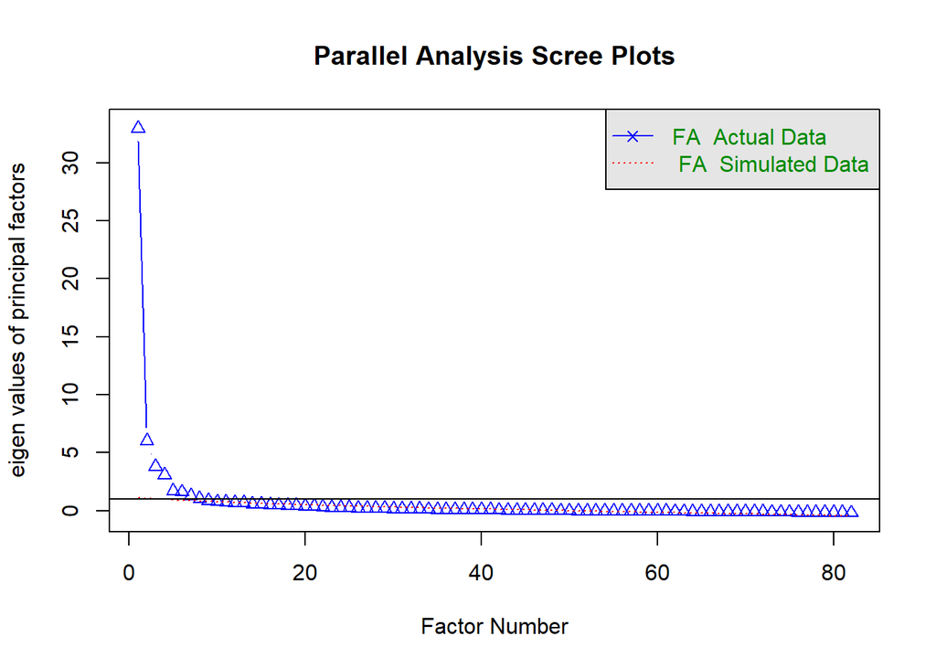

```
## Parallel analysis suggests that the number of factors =  11  and the number of components =  NA
```

```r
# test for the number of factors using parallel analysis
psych::fa.parallel(ph1b_fa_cov, n.obs = 465, fa = "fa", fm = "pa", SMC = T, n.iter = 100)
```

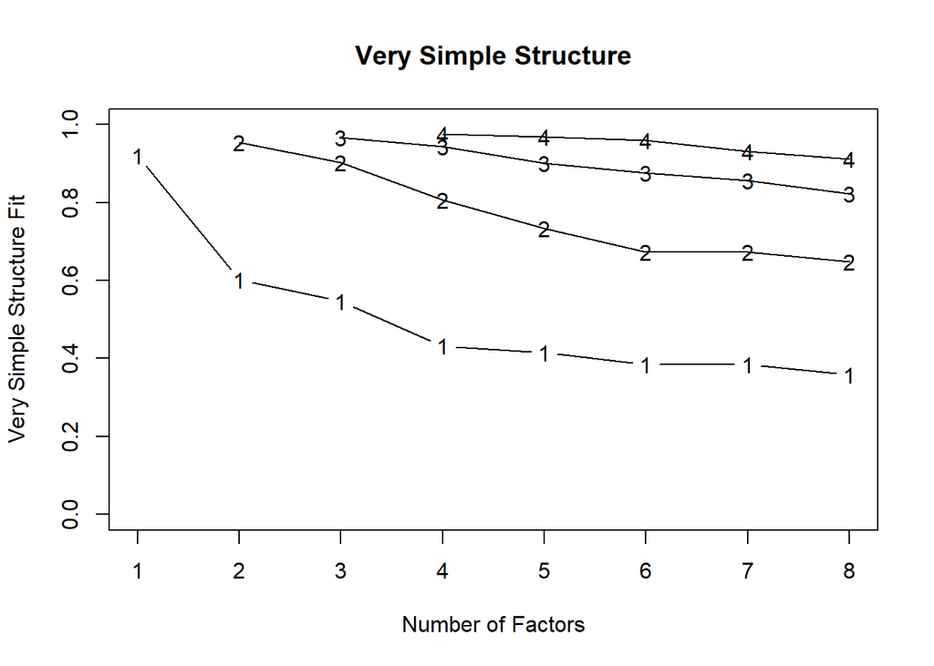

```
##
## Very Simple Structure
## Call: psych::vss(x = ph1b_fa_cov, fm = "pa", n.obs = 465)
## VSS complexity 1 achieves a maximimum of 0.92  with  1  factors
## VSS complexity 2 achieves a maximimum of 0.95  with  2  factors
##
## The Velicer MAP achieves a minimum of 0.01  with  8  factors
## BIC achieves a minimum of  -10377.53  with  7  factors
## Sample Size adjusted BIC achieves a minimum of  -1791.19  with  8  factors
##
## Statistics by number of factors
##   vss1 vss2    map  dof chisq     prob sqresid  fit RMSEA    BIC SABIC complex
## 1 0.92 0.00 0.0271 3239 17051  0.0e+00      95 0.92 0.096  -2843  7437     1.0
## 2 0.60 0.95 0.0165 3158 13394  0.0e+00      56 0.95 0.083  -6003  4020     1.4
## 3 0.55 0.90 0.0137 3078 11047  0.0e+00      40 0.97 0.075  -7858  1911     1.6
## 4 0.43 0.81 0.0095 2999  9143  0.0e+00      29 0.98 0.066  -9277   241     2.0
## 5 0.42 0.73 0.0087 2921  8238  0.0e+00      25 0.98 0.063  -9703  -432     2.2
## 6 0.38 0.67 0.0080 2844  7286  0.0e+00      21 0.98 0.058 -10182 -1156     2.3
## 7 0.39 0.67 0.0074 2768  6624 1.2e-315      19 0.98 0.055 -10378 -1593     2.4
## 8 0.36 0.65 0.0073 2693  6202 5.4e-277      17 0.99 0.053 -10338 -1791     2.5
##   eChisq  SRMR eCRMS   eBIC
## 1  30095 0.099 0.100  10201
## 2  14798 0.069 0.071  -4598
## 3   9074 0.054 0.056  -9831
## 4   5212 0.041 0.043 -13208
## 5   4105 0.036 0.039 -13836
## 6   3129 0.032 0.034 -14339
## 7   2521 0.029 0.031 -14480
## 8   2144 0.026 0.029 -14397
```

```r
psych::vss(ph1b_fa_cov, n.obs = 465, fm = "pa")
```

The factor loadings after rotation will be interpreted and reported.

```r
# rotate factor solution
ph1b_fa_mod <- psych::fa(ph1b_fa_cov, n.obs = 465, nfactors = 8, fm = "pa", SMC = T, n.iter = 1, p = .05)
ph1b_fa_mod
```

```
## Factor Analysis using method =  pa
## Call: psych::fa(r = ph1b_fa_cov, nfactors = 8, n.obs = 465, n.iter = 1,
##     SMC = T, fm = "pa", p = 0.05)
## Standardized loadings (pattern matrix) based upon correlation matrix
##                   PA2   PA3   PA1   PA5   PA6   PA4   PA8   PA7   h2   u2 com
## stars_test1      0.43  0.03  0.13  0.34  0.07 -0.12  0.03  0.16 0.60 0.40 2.7
## stars_int1       0.11  0.04  0.64  0.00  0.12 -0.04 -0.03  0.12 0.61 0.39 1.2
## stars_help1      0.08  0.89 -0.08  0.01  0.04 -0.07 -0.09  0.04 0.76 0.24 1.1
## stars_test2      0.31  0.12  0.21  0.36  0.10 -0.19 -0.01  0.08 0.56 0.44 3.8
## stars_int2       0.18  0.02  0.58 -0.02  0.18  0.06 -0.08  0.05 0.60 0.40 1.5
## stars_int3       0.11  0.06  0.57  0.02  0.07  0.05  0.00  0.20 0.60 0.40 1.4
## stars_int4       0.20  0.15  0.47 -0.04  0.14 -0.20  0.05  0.07 0.49 0.51 2.3
## stars_test3      0.68  0.11  0.13 -0.04  0.11 -0.05  0.06 -0.03 0.68 0.32 1.2
## stars_int5       0.05  0.08  0.34 -0.11 -0.06  0.34  0.06  0.20 0.38 0.62 3.1
## stars_test4      0.67  0.06  0.11 -0.01  0.02 -0.06  0.09  0.03 0.60 0.40 1.1
## stars_int6       0.15  0.05  0.55 -0.11  0.19  0.10  0.01  0.05 0.58 0.42 1.6
## stars_int7       0.08  0.20  0.35  0.15  0.13  0.04  0.03  0.19 0.58 0.42 3.2
## stars_test5      0.13  0.12  0.13 -0.05  0.08 -0.11  0.54  0.11 0.54 0.46 1.6
## stars_int8       0.12  0.11  0.43 -0.06  0.10  0.13  0.01  0.06 0.41 0.59 1.7
## stars_test6      0.78  0.03  0.12 -0.05 -0.04  0.05  0.06  0.04 0.70 0.30 1.1
## stars_help2      0.05  0.90 -0.05 -0.03  0.01 -0.02 -0.05  0.12 0.79 0.21 1.1
## stars_int9      -0.03  0.03  0.37 -0.05  0.08  0.20  0.13  0.14 0.37 0.63 2.4
## stars_int10      0.05  0.07  0.39  0.10 -0.05  0.11  0.26  0.33 0.60 0.40 3.2
## stars_help3      0.02  0.85  0.04 -0.07 -0.01 -0.03  0.03  0.13 0.77 0.23 1.1
## stars_int11      0.14  0.02  0.64  0.08  0.05  0.01  0.02  0.10 0.65 0.35 1.2
## stars_test7      0.15  0.03  0.14  0.54  0.14 -0.06  0.03  0.19 0.64 0.36 1.7
## stars_test8      0.18  0.07 -0.02 -0.05  0.14  0.00  0.55  0.20 0.55 0.45 1.7
## stars_help4     -0.05  0.78  0.07 -0.11  0.06 -0.03  0.07  0.13 0.70 0.30 1.1
## stars_m_test1    0.20  0.04  0.11  0.49 -0.02  0.06  0.13 -0.15 0.64 0.36 1.9
## stars_m_int1    -0.05  0.01  0.75  0.10  0.02  0.08  0.07 -0.09 0.73 0.27 1.1
## stars_m_help1   -0.01  0.87 -0.04  0.09 -0.02 -0.03  0.00 -0.15 0.76 0.24 1.1
## stars_m_test2    0.13  0.05  0.23  0.50  0.03 -0.09  0.12 -0.19 0.63 0.37 2.2
## stars_m_int2     0.00  0.07  0.57  0.06  0.13  0.11  0.02 -0.19 0.59 0.41 1.5
## stars_m_int3    -0.08  0.02  0.65  0.09  0.06  0.07  0.10 -0.02 0.62 0.38 1.2
## stars_m_int4    -0.08  0.13  0.33  0.27  0.06  0.13  0.24 -0.11 0.64 0.36 4.1
## stars_m_test3    0.46  0.02  0.04  0.17 -0.02  0.10  0.20 -0.33 0.71 0.29 2.7
## stars_m_test4    0.46  0.11  0.08  0.06 -0.08  0.12  0.19 -0.25 0.61 0.39 2.5
## stars_m_int6    -0.05 -0.03  0.42 -0.04 -0.03  0.43  0.07  0.07 0.47 0.53 2.2
## stars_m_test5   -0.06  0.07  0.18  0.09  0.01 -0.08  0.67 -0.07 0.63 0.37 1.3
## stars_m_int8    -0.06  0.07  0.45  0.08  0.09  0.12  0.26 -0.17 0.61 0.39 2.4
```

[output cut: 76 more lines]

```
## The total number of observations was  465  with Likelihood Chi Square =  6202.37  with prob <  5.4e-277
##
## Tucker Lewis Index of factoring reliability =  0.856
## RMSEA index =  0.053  and the 90 % confidence intervals are  0.051 0.055
## BIC =  -10338.13
## Fit based upon off diagonal values = 1
## Measures of factor score adequacy
##                                                    PA2  PA3  PA1  PA5  PA6  PA4
## Correlation of (regression) scores with factors   0.98 0.98 0.97 0.96 0.96 0.95
## Multiple R square of scores with factors          0.95 0.96 0.94 0.91 0.93 0.89
## Minimum correlation of possible factor scores     0.91 0.92 0.87 0.83 0.85 0.79
##                                                    PA8  PA7
## Correlation of (regression) scores with factors   0.93 0.92
## Multiple R square of scores with factors          0.87 0.84
## Minimum correlation of possible factor scores     0.73 0.68
```

Check that most residuals are lower than 0.05.

```r
# check residuals
residuals <- psych::factor.residuals(ph1b_fa_corr, ph1b_fa_mod)
residuals %>% dplyr::as_tibble(., rownames = "item")
```

```
## # A tibble: 82 x 83
##    item  stars_test1 stars_int1 stars_help1 stars_test2 stars_int2 stars_int3
##    <chr>       <dbl>      <dbl>       <dbl>       <dbl>      <dbl>      <dbl>
##  1 star~    0.402      -0.00128     0.0237      0.0489    0.000591    0.00492
##  2 star~   -0.00128     0.392       0.0174      0.0130    0.00594     0.0458
##  3 star~    0.0237      0.0174      0.242      -0.00584   0.0101     -0.00280
##  4 star~    0.0489      0.0130     -0.00584     0.435    -0.00758     0.0271
##  5 star~    0.000591    0.00594     0.0101     -0.00758   0.401      -0.0119
##  6 star~    0.00492     0.0458     -0.00280     0.0271   -0.0119      0.396
##  7 star~    0.0510     -0.00347     0.00755     0.00657   0.0327     -0.0310
##  8 star~    0.00923     0.00420    -0.00345     0.0585    0.0273     -0.0342
##  9 star~   -0.0250     -0.00224     0.0302     -0.0178    0.0233      0.00887
## 10 star~   -0.0471     -0.0337     -0.0347     -0.0138   -0.0102     -0.0129
## # ... with 72 more rows, and 76 more variables: stars_int4 <dbl>,
## #   stars_test3 <dbl>, stars_int5 <dbl>, stars_test4 <dbl>, stars_int6 <dbl>,
## #   stars_int7 <dbl>, stars_test5 <dbl>, stars_int8 <dbl>, stars_test6 <dbl>,
## #   stars_help2 <dbl>, stars_int9 <dbl>, stars_int10 <dbl>, stars_help3 <dbl>,
## #   stars_int11 <dbl>, stars_test7 <dbl>, stars_test8 <dbl>, stars_help4 <dbl>,
## #   stars_m_test1 <dbl>, stars_m_int1 <dbl>, stars_m_help1 <dbl>,
## #   stars_m_test2 <dbl>, stars_m_int2 <dbl>, stars_m_int3 <dbl>,
## #   stars_m_int4 <dbl>, stars_m_test3 <dbl>, stars_m_test4 <dbl>,
## #   stars_m_int6 <dbl>, stars_m_test5 <dbl>, stars_m_int8 <dbl>,
## #   stars_m_test6 <dbl>, stars_m_help2 <dbl>, stars_m_int10 <dbl>,
## #   stars_m_help3 <dbl>, stars_m_int11 <dbl>, stars_m_test7 <dbl>,
## #   stars_m_test8 <dbl>, stars_m_help4 <dbl>, rmars_test1 <dbl>,
## #   rmars_test2 <dbl>, rmars_test3 <dbl>, rmars_test4 <dbl>, rmars_test5 <dbl>,
## #   rmars_test6 <dbl>, rmars_test7 <dbl>, rmars_test8 <dbl>, rmars_test9 <dbl>,
## #   rmars_test10 <dbl>, rmars_num1 <dbl>, rmars_num2 <dbl>, rmars_num3 <dbl>,
## #   rmars_num4 <dbl>, rmars_num5 <dbl>, rmars_course1 <dbl>,
## #   rmars_course2 <dbl>, rmars_course3 <dbl>, rmars_course4 <dbl>,
## #   rmars_course5 <dbl>, rmars_s_test1 <dbl>, rmars_s_test2 <dbl>,
## #   rmars_s_test3 <dbl>, rmars_s_test4 <dbl>, rmars_s_test5 <dbl>,
## #   rmars_s_test6 <dbl>, rmars_s_test7 <dbl>, rmars_s_test8 <dbl>,
## #   rmars_s_test9 <dbl>, rmars_s_test10 <dbl>, rmars_s_num2 <dbl>,
## #   rmars_s_num3 <dbl>, rmars_s_num4 <dbl>, rmars_s_num5 <dbl>,
## #   rmars_s_course1 <dbl>, rmars_s_course2 <dbl>, rmars_s_course3 <dbl>,
## #   rmars_s_course4 <dbl>, rmars_s_course5 <dbl>
```

Plot factor solution.

[figure not shown]

```r
# draw path diagram of factor solution (will likely need modifying when used with real data)
psych::fa.diagram(ph1b_fa_mod, cut = 0.4)
```

Finally, calculate reliability of retained factors.

```r
# create dataframes containing raw scores for each factor, e.g:
# factor_1 <- dplyr::select(ph1b_fa_data, c("stars_test1", "stars_test2", "stars_test3"))

# repeat for each factor
```

```r
# calculate the point estimate and confidence interval for omega reliability coefficient
# MBESS::ci.reliability(factor_1, type = "omega", conf.level = 0.95, interval.type = "bca", B = 1000)

# repeat for each factor
```